# Project 2: Data Mining, Classification, Prediction

SDS322E

# Mining, Classification, Prediction

## Kelsey Garcia - kg29435

### Introduction

The dataset used for this project contains the hurricanes that have impacted the United States since the year 1950 to today. The variables included in this dataset are as follows: “name” gives the name given to the hurricane, “year” which represents the year of landfall, “winds_mph” which represents the maximum wind speeds along the US coastline during landfall in mph, “pressure_mb” represents the atmospheric during landfall in millibars, “deaths” represents the number of deaths caused by the hurricane, “gender_name” is a binary character variable which represents the gender of the name of the hurricane, and “total_damage” represents the total property damage in 2014 USDs.

This data was particularly interesting to me because this data was first studied to determine whether or not female-gendered named hurricanes were taken less seriously by the US public and therefore resulted in higher amounts of property damage.

```r
library(readr)
hurricanes <- read_csv("~/project2/hurricNamed.csv")
hurricanes
```

```
## # A tibble: 94 x 13
##    X1    Name   Year LF.WindsMPH LF.PressureMB LF.times BaseDamage NDAM2014
##    <chr> <chr> <dbl>       <dbl>         <dbl>    <dbl>      <dbl>    <dbl>
##  1 Easy… Easy   1950         120           958        1       3.3      1870
##  2 King… King   1950         130           955        1      28        6030
##  3 Able… Able   1952          85           985        1       2.75      170
##  4 Barb… Barb…  1953          85           987        1       1          65
##  5 Flor… Flor…  1953          85           985        1       0.2        18
##  6 Caro… Carol  1954         120           960        2     460.      21375
##  7 Edna… Edna   1954         120           954        1      40        3520
##  8 Haze… Hazel  1954         145           938        1     281       28500
##  9 Conn… Conn…  1955         120           962        1      40        2270
## 10 Dian… Diane  1955          85           987        1     200       17250
## # … with 84 more rows, and 5 more variables: AffectedStates <chr>,
## #   firstLF <date>, deaths <dbl>, mf <chr>, BaseDam2014 <dbl>
```

```r
## Cleaning up
library(tidyverse)
hurricanes <- hurricanes %>% select(2:5, 11:13)
hurricanes <- as.data.frame(hurricanes)
names(hurricanes) <- c("name", "year", "winds_mph", "pressure_mb",
    "deaths", "gender_name", "total_damage")
hurricanes$gender_num = ifelse(hurricanes$gender_name == "f",
    1, 0)
hurricanes
```

```
##        name year winds_mph pressure_mb deaths gender_name total_damage
## 1      Easy 1950       120         958      2           f    32.419419
## 2      King 1950       130         955      4           m   275.073859
## 3      Able 1952        85         985      3           m    24.569434
## 4   Barbara 1953        85         987      1           f     8.867416
## 5  Florence 1953        85         985      0           f     1.773483
## 6     Carol 1954       120         960     60           f  4050.686353
## 7      Edna 1954       120         954     20           f   352.059480
## 8     Hazel 1954       145         938     20           f  2473.217844
## 9    Connie 1955       120         962      0           f   353.373134
## 10    Diane 1955        85         987    200           f  1766.865672
## 11     Ione 1955       120         960      7           m   777.730097
## 12   Flossy 1956       105         975     15           f   217.610294
##    gender_num
## 1           1
## 2           0
## 3           0
## 4           1
## 5           1
## 6           1
## 7           1
## 8           1
## 9           1
## 10          1
## 11          0
## 12          1
##  [ reached 'max' / getOption("max.print") -- omitted 82 rows ]
```

### Cluster Analysis

#### PAM Clustering

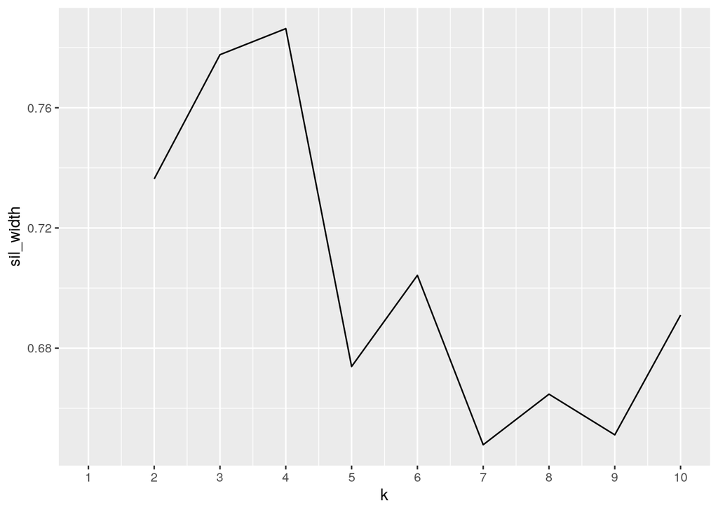

```r
library(cluster)
## finding the best fitting number of clusters scaling the
## data
hurricanes_dat <- hurricanes %>% select(-name, -year, -gender_name)
sil_width <- vector()
#### running all options for clustering
for (i in 2:10) {
    pam_fit <- pam(hurricanes_dat, k = i)
    sil_width[i] <- pam_fit$silinfo$avg.width
}
#### visualizing best clustering based on sil_width
ggplot() + geom_line(aes(x = 1:10, y = sil_width)) + scale_x_continuous(name = "k",
    breaks = 1:10)
```

```r
## clustering based on 3 clusters
hurri_pam <- pam(hurricanes, k = 3)
hurri_pam
```

```
## Medoids:
##      ID name year winds_mph pressure_mb deaths gender_name total_damage
## [1,]  9   NA 1955       120         962      0          NA     353.3731
## [2,] 79   NA 2004       105         960      7          NA   11280.2541
## [3,] 94   NA 2012        75         942    159          NA   51560.5809
##      gender_num
## [1,]          1
## [2,]          1
## [3,]          1
## Clustering vector:
##  [1] 1 1 1 1 1 1 1 1 1 1 1 1 1 1 1 1 1 1 1 1 1 1 1 1 2 1 1 1 1 2 1 1 1 1 2 1 1 1
## [39] 1 1 1 2 1 1 1 1 1 1 1 1 1 1 1 1 1 1 2 1 1 3 1 1 1 1 1 1 1 1 1 1 2 1 1 1 1 1
## [77] 2 1 2 2 2 1 1 3 1 2 2 1 1 1 2 2 1 3
## Objective function:
##    build     swap
## 2440.168 2329.477
##
## Available components:
##  [1] "medoids"    "id.med"     "clustering" "objective"  "isolation"
##  [6] "clusinfo"   "silinfo"    "diss"       "call"       "data"
```

```r
hurricanes$cluster = hurri_pam$cluster
hurricanes
```

```
##        name year winds_mph pressure_mb deaths gender_name total_damage
## 1      Easy 1950       120         958      2           f    32.419419
## 2      King 1950       130         955      4           m   275.073859
## 3      Able 1952        85         985      3           m    24.569434
## 4   Barbara 1953        85         987      1           f     8.867416
## 5  Florence 1953        85         985      0           f     1.773483
## 6     Carol 1954       120         960     60           f  4050.686353
## 7      Edna 1954       120         954     20           f   352.059480
## 8     Hazel 1954       145         938     20           f  2473.217844
## 9    Connie 1955       120         962      0           f   353.373134
## 10    Diane 1955        85         987    200           f  1766.865672
## 11     Ione 1955       120         960      7           m   777.730097
##    gender_num cluster
## 1           1       1
## 2           0       1
## 3           0       1
## 4           1       1
## 5           1       1
## 6           1       1
## 7           1       1
## 8           1       1
## 9           1       1
## 10          1       1
## 11          0       1
##  [ reached 'max' / getOption("max.print") -- omitted 83 rows ]
```

```r
## silhouette width with 4 clusters
hurri_pam$silinfo$avg.width
```

```
## [1] 0.7775697
```

#### Visualizing Clusters

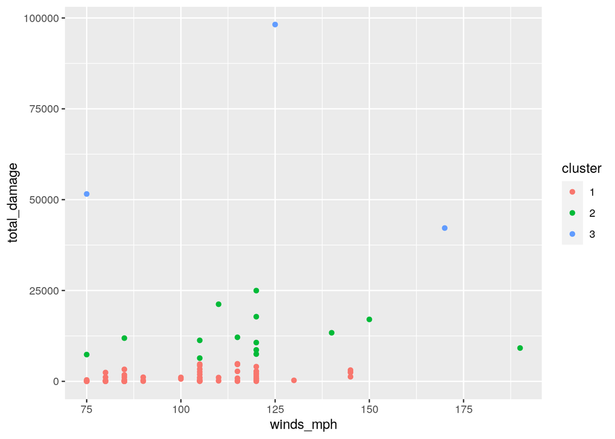

```r
## visualizing based on only two variables
library(cluster)
pamclust <- hurricanes_dat %>% mutate(cluster = as.factor(hurri_pam$clustering))
pamclust %>% ggplot(aes(winds_mph, total_damage, color = cluster)) +
    geom_point()
```

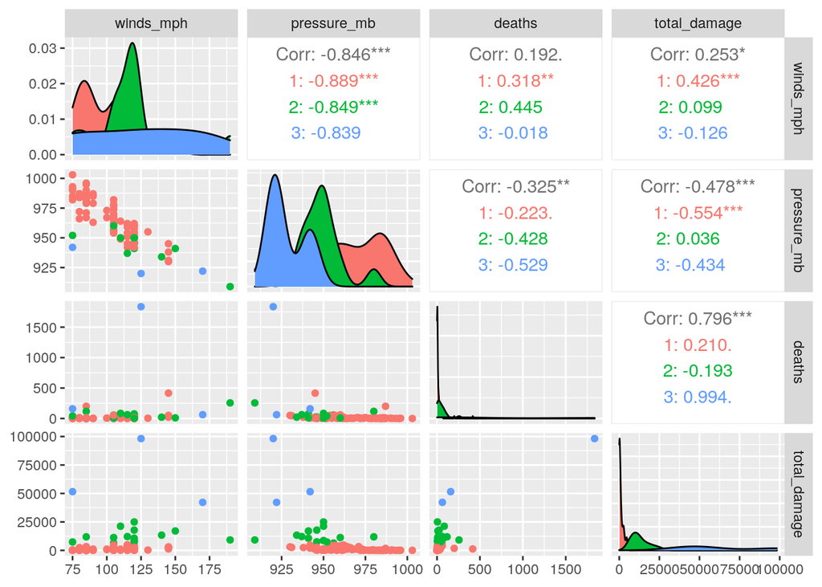

```r
## visualizing on all pairwise combinations of variables
library(GGally)
ggpairs(pamclust, columns = 1:4, aes(color = cluster))
```

PAM clustering was performed to understand how the observations were best grouped based on the four variables of “winds_mph”,“pressure_mb”,“deaths”, and “total_damage”. In the clustering data set, the “gender_name” character variable was changed to a binary numeric variable where 0=male and 1=female for future analysis. When finding the silhouette widths of clustering the data with 2 clusters to 10 clusters the highest silhouette width (and therefore the best fit) was using 4 clusters, with a silhouette width of 0.78. However, the number of clusters used as the best clustering scenario was 3 clusters because the silhouette width was 0.77 and allowed for better interpretation in the ggpairs plot.

### Dimensionality Reduction with PCA

```r
## Making Principle Components
hurricanes_dat <- data.frame(scale(hurricanes_dat))
hurricanes_pca <- princomp(hurricanes_dat, center = T, scale = T)

## Visualizing the number of PCs to keep - 3 PCs
eigval <- hurricanes_pca$sdev^2
varprop = round(eigval/sum(eigval), 2)
varprop
```

```
## Comp.1 Comp.2 Comp.3 Comp.4 Comp.5
##   0.49   0.24   0.20   0.04   0.02
```

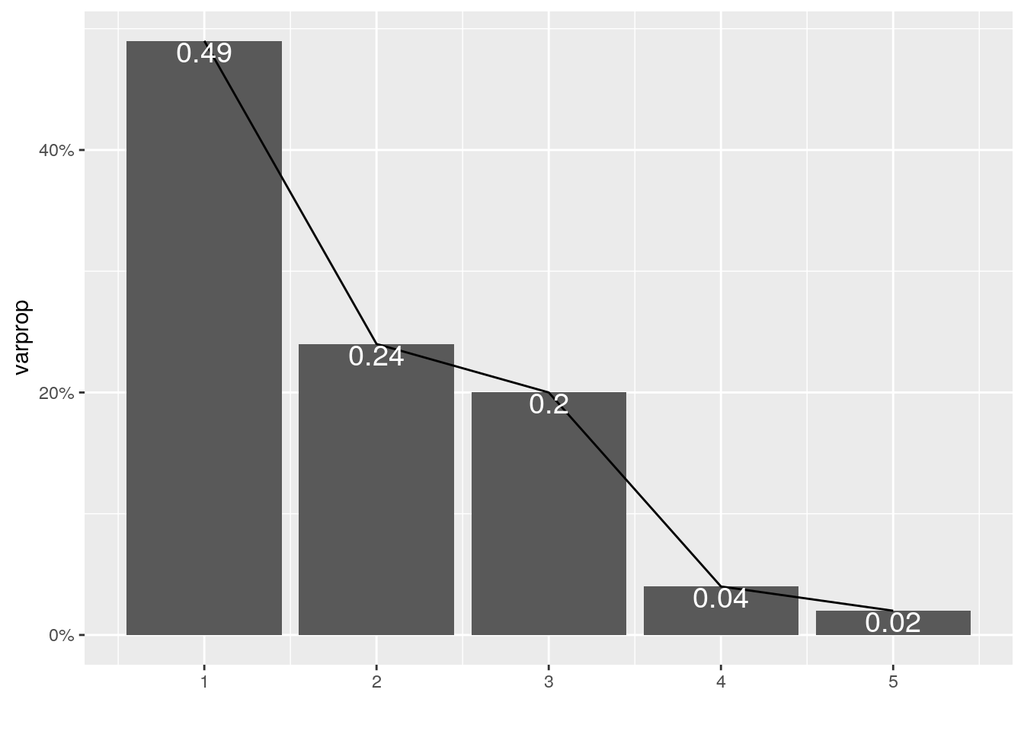

```r
ggplot() + geom_bar(aes(y = varprop, x = 1:5), stat = "identity") +
    xlab("") + geom_path(aes(y = varprop, x = 1:5)) + geom_text(aes(x = 1:5,
    y = varprop, label = round(varprop, 2)), vjust = 1, col = "white",
    size = 5) + scale_y_continuous(breaks = seq(0, 0.6, 0.2),
    labels = scales::percent) + scale_x_continuous(breaks = 1:10)
```

The principal component analysis was done to identify what trends can be seen in the variables and which variable relationships predict the variance of data best. A scree plot was made to identify how many principle components were necessary to explain at least 80% of the variance in the dataset. According to the scree plot, three PCs were needed to satisfy that criteria. However, upon looking at the loadings summary, the third PC was found to only be predicted by the binary factor which had no relationship with the other numeric variables in the data. Therefore, further PCA techniques were only analyzed for the top two principle components which accounted for 74% of the data’s total variance.

```r
## Interpreting PCs
summary(hurricanes_pca, loadings = T)
```

```
## Importance of components:
##                           Comp.1    Comp.2    Comp.3    Comp.4     Comp.5
## Standard deviation     1.5608916 1.0970859 0.9951678 0.4629273 0.31963686
## Proportion of Variance 0.4925161 0.2433079 0.2002016 0.0433212 0.02065326
## Cumulative Proportion  0.4925161 0.7358239 0.9360255 0.9793467 1.00000000
##
## Loadings:
##              Comp.1 Comp.2 Comp.3 Comp.4 Comp.5
## winds_mph     0.468  0.571         0.386  0.553
## pressure_mb  -0.544 -0.405         0.322  0.657
## deaths        0.466 -0.549         0.637 -0.270
## total_damage  0.512 -0.456        -0.576  0.434
## gender_num                 -0.991 -0.101
```

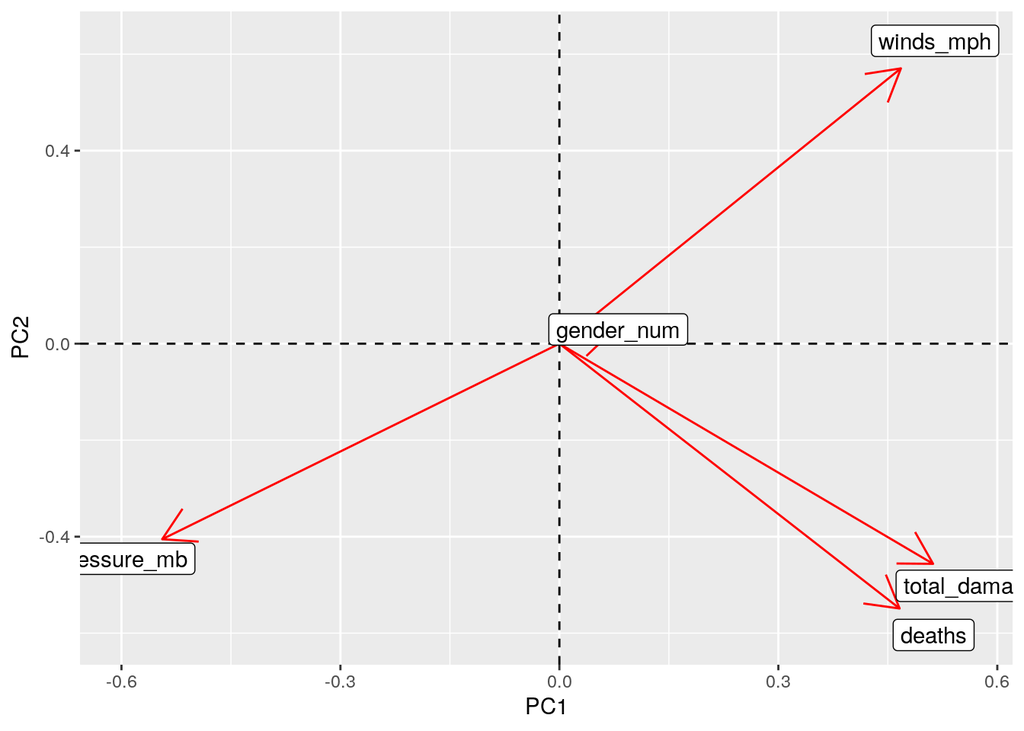

```r
hurricanes_pca$loadings[1:5, 1:2] %>% as.data.frame %>% rownames_to_column %>%
    ggplot() + geom_hline(aes(yintercept = 0), lty = 2) + geom_vline(aes(xintercept = 0),
    lty = 2) + ylab("PC2") + xlab("PC1") + geom_segment(aes(x = 0,
    y = 0, xend = Comp.1, yend = Comp.2), arrow = arrow(), col = "red") +
    geom_label(aes(x = Comp.1 * 1.1, y = Comp.2 * 1.1, label = rowname))
```

A biplot was made to analyze the relationships of the variables in the dataset with the principle components. According to the biplot, PC1 shows that there is an opposite relationship such that when “winds_mph”, “total_damage”, and “deaths” are high the “pressure_mb” values are low. This shows that stronger, more damaging hurricanes have lower atmospheric pressure at landfall. PC2 shows that when “winds_mph” are high, “pressure_mb”,“total_damage”, and “deaths” are low. This shows a somewhat contrary relationship to the PC1 variable.

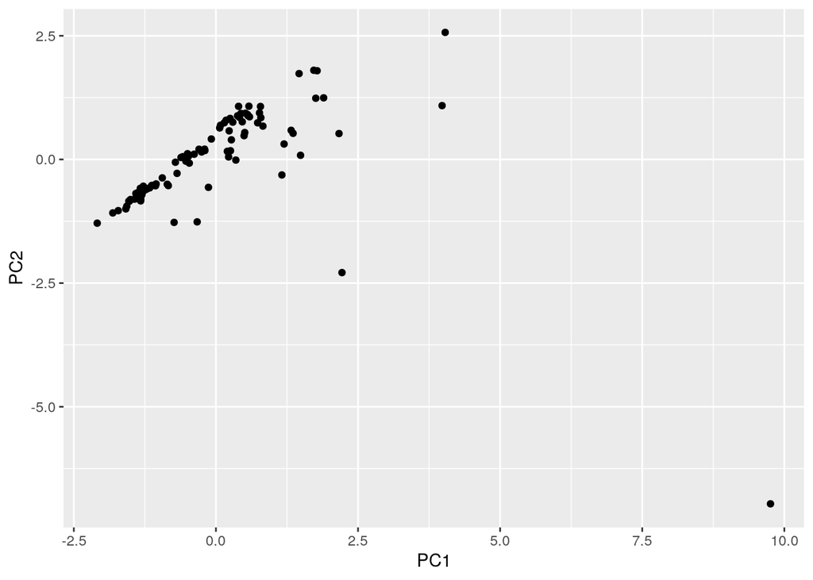

```r
## Visualizing PC scores
hurri_pca_df <- data.frame(Name = hurricanes$name, PC1 = hurricanes_pca$scores[,
    1], PC2 = hurricanes_pca$scores[, 2])
library(factoextra)
ggplot(hurri_pca_df, aes(PC1, PC2)) + geom_point()
```

Finally, PC1 and PC2 were plotted against one another to show that there is seemingly a positive correlation between the two principle compoenents such that when PC1 increases, PC2 increases as well. To score high on PC1 means that the total damage is higher due to its associated hurricane variables (high winds, low atmospheric pressure, and higher number of deaths).

### Linear Classifier

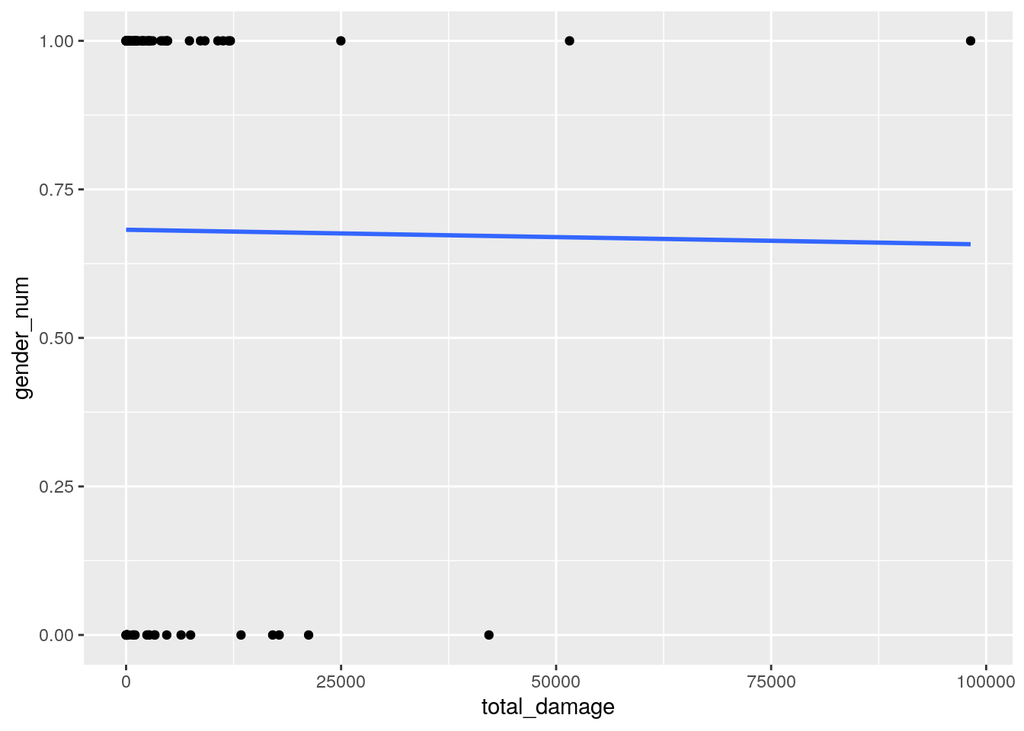

```r
# linear regression model
hurricanes %>% ggplot(aes(total_damage, gender_num)) + geom_point() +
    geom_smooth(method = "lm", se = F) + ylim(0, 1)
```

```r
# predicting binary gender_num variable from all of the
# numeric variables
fit <- lm(gender_num ~ total_damage + winds_mph + deaths + pressure_mb,
    data = hurricanes)
score <- predict(fit, type = "response")
score %>% round(3)
```

```
##     1     2     3     4     5     6     7     8     9    10    11    12    13
## 0.718 0.724 0.656 0.650 0.654 0.712 0.738 0.751 0.703 0.781 0.709 0.686 1.049
##    14    15    16    17    18    19    20    21    22    23    24    25    26
## 0.745 0.655 0.751 0.786 0.663 0.786 0.628 0.685 0.680 0.753 0.681 0.693 0.664
##    27    28    29    30    31    32    33    34    35    36    37    38    39
## 0.660 0.731 0.674 0.922 0.733 0.668 0.668 0.629 0.619 0.724 0.715 0.665 0.629
##    40    41    42    43    44    45    46    47    48    49    50    51    52
## 0.651 0.688 0.664 0.740 0.669 0.739 0.610 0.648 0.686 0.739 0.659 0.692 0.644
##    53    54    55    56    57    58    59    60    61    62    63    64    65
## 0.646 0.635 0.657 0.659 0.637 0.659 0.690 0.368 0.712 0.674 0.709 0.681 0.691
##    66    67    68    69    70    71    72    73    74    75    76    77    78
## 0.662 0.693 0.650 0.666 0.733 0.692 0.642 0.695 0.667 0.709 0.686 0.570 0.658
##    79    80    81    82    83    84    85    86    87    88    89    90    91
## 0.590 0.562 0.641 0.636 0.726 1.086 0.661 0.677 0.456 0.654 0.684 0.713 0.559
##    92    93    94
## 0.680 0.676 0.291
```

```r
score
```

```
##         1         2         3         4         5         6         7         8
## 0.7180156 0.7235421 0.6556620 0.6495308 0.6536414 0.7115834 0.7376382 0.7507785
##         9        10        11        12        13        14        15        16
## 0.7032639 0.7807652 0.7085452 0.6857002 1.0487301 0.7453197 0.6554085 0.7514477
##        17        18        19        20        21        22        23        24
## 0.7857028 0.6631449 0.7861620 0.6284915 0.6846541 0.6804053 0.7532808 0.6805823
##        25        26        27        28        29        30        31        32
## 0.6931525 0.6637362 0.6603157 0.7312923 0.6737479 0.9215442 0.7331963 0.6675404
##        33        34        35        36        37        38        39        40
## 0.6679287 0.6290470 0.6192122 0.7237975 0.7154730 0.6647017 0.6292677 0.6512845
##        41        42        43        44        45        46        47        48
## 0.6882768 0.6640578 0.7399192 0.6693575 0.7394308 0.6104692 0.6481712 0.6864221
##        49        50        51        52        53        54        55        56
## 0.7387303 0.6587553 0.6924335 0.6439177 0.6455354 0.6349075 0.6569586 0.6591826
##        57        58        59        60        61        62        63        64
## 0.6373897 0.6592106 0.6896413 0.3680790 0.7115158 0.6739610 0.7092013 0.6806154
##        65        66        67        68        69        70        71        72
## 0.6914688 0.6621865 0.6932924 0.6500546 0.6657025 0.7328675 0.6920735 0.6422240
##        73        74        75        76        77        78        79        80
## 0.6947818 0.6674666 0.7092935 0.6857073 0.5699726 0.6583048 0.5896685 0.5620927
##        81        82        83        84        85        86        87        88
## 0.6414208 0.6360551 0.7262430 1.0856897 0.6610581 0.6765463 0.4556680 0.6535633
##        89        90        91        92        93        94
## 0.6843924 0.7127861 0.5587904 0.6804363 0.6756000 0.2912193
```

```r
## in-sample performance
class_diag(score, truth = hurricanes$gender_num, positive = 1)
```

```
##            acc   sens   spec    ppv  f1    ba    auc
## Metrics 0.6702 0.9688 0.0333 0.6813 0.8 0.501 0.6552
```

```r
## confusion matrix
table(truth = factor(hurricanes$gender_num == 1, levels = c("TRUE",
    "FALSE")), prediction = factor(score > 0.5, levels = c("TRUE",
    "FALSE"))) %>% addmargins()
```

```
##        prediction
## truth   TRUE FALSE Sum
##   TRUE    62     2  64
##   FALSE   29     1  30
##   Sum     91     3  94
```

```r
# K-means cross-validation of linear classifier using all
# numeric variables in 'hurricanes'
k = 10

data <- hurricanes[sample(nrow(hurricanes)), ]
folds <- cut(seq(1:nrow(hurricanes)), breaks = k, labels = F)

diags <- NULL

for (i in 1:k) {
    train <- data[folds != i, ]
    test <- data[folds == i, ]
    truth <- test$gender_num
}

fit <- lm(gender_num ~ total_damage + winds_mph + deaths + pressure_mb,
    data = train, family = "binomial")
probs <- predict(fit, newdata = test, type = "response")

## out-of-sample performance of classifier
diags <- rbind(diags, class_diag(probs, truth, positive = 1))
summarize_all(diags, mean)
```

```
##   acc sens spec ppv     f1  ba    auc
## 1 0.9    1    0 0.9 0.9474 0.5 0.6667
```